# Poverty and Test Performance in New York Public Schools

Charlie Ma

2026-09-21

```r
library(tidyverse)
library(knitr)
```

```r
merged <- read_csv("data/processed/nys_merged.csv", show_col_types = FALSE) |>
  mutate(poverty_group = factor(poverty_group, levels = c("low", "medium", "high")))

tbl <- function(x) read_csv(paste0("output/tables/", x, ".csv"), show_col_types = FALSE)
```

## Question

What does the data say about poverty and test performance in NY public schools — how big is the gap, is it closing, and does free/reduced lunch access change it?

Data: `nys_schools.csv` (one row per school-year, 2008–2017, NYS Education Department) and `nys_acs.csv` (one row per county-year, 2009–2016, American Community Survey).

## What I did

**`1_clean.R`**

- Recoded `-99` to `NA`. It appears in both numeric and character columns, so each type needs its own `na_if()`.
- Dropped 24 exact duplicate rows, and 19 rows that were `-99` in every field but the school name.
- Kept the 1,725 rows with a missing `district_name` — those are charter schools, which have no district. Dropping them would lose most of NYC.
- Set `per_free_lunch` / `per_reduced_lunch` to `NA` where they exceed 1 (44 rows, max 257) or sum above 1 (42 rows). The two are mutually exclusive tiers of the same enrollment, so the sum can’t exceed 100%.
- Split counties into **terciles** of poverty rate (low ≤ 11.7%, medium 11.7–14.4%, high > 14.4%), pooled across years. Poverty clusters between 11% and 15%, so round cutoffs would empty the middle group; pooling keeps “high poverty” meaning the same thing in 2009 and 2016.
- Converted scores to **z-scores within year**. The state changed its test in 2013 (max ELA ~720 → ~355), so raw scores aren’t comparable across years.

Result: 35,620 rows.

**`2_transform.R`** — `left_join` on `county_name` **and** `year`. County alone fans each school-year across all 8 ACS years (284,960 rows). Left rather than inner keeps 2008 and 2017 usable for school-level questions.

**`3_analyze.R`** / **`4_plot.R`** — summary tables and the two figures below.

## Q1: How large is the gap?

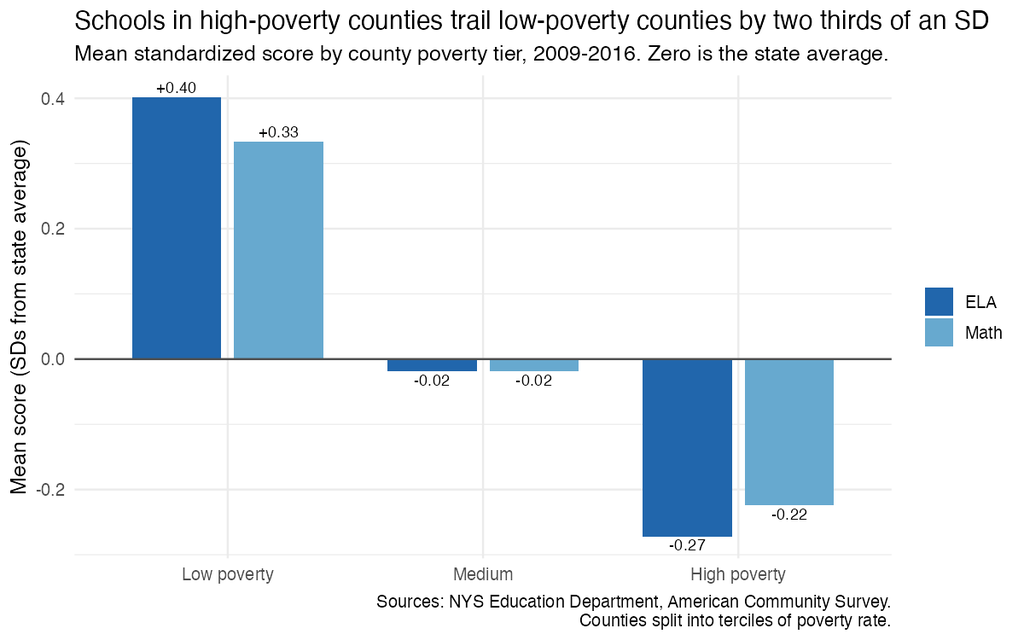

```r
include_graphics("output/figures/2_performance_by_poverty.png")
```

```r
kable(tbl("by_poverty"), digits = 3,
      caption = "Performance by county poverty tier, 2009-2016")
```

Performance by county poverty tier, 2009-2016

| poverty_group | n_school_years | per_free_reduced | mean_ela_z | mean_math_z |
| --- | --- | --- | --- | --- |
| low | 9136 | 0.310 | 0.401 | 0.333 |
| medium | 7063 | 0.516 | -0.019 | -0.018 |
| high | 12351 | 0.701 | -0.272 | -0.224 |

```r
kable(tbl("extremes"), digits = 3, caption = "Top 5 and bottom 5 counties by poverty rate")
```

Top 5 and bottom 5 counties by poverty rate

| group | county_name | per_poverty | per_free_reduced | mean_ela_z | mean_math_z |
| --- | --- | --- | --- | --- | --- |
| top 5 poverty | BRONX | 0.287 | 0.859 | -0.767 | -0.698 |
| top 5 poverty | KINGS | 0.225 | 0.774 | -0.278 | -0.232 |
| top 5 poverty | MONTGOMERY | 0.177 | 0.539 | -0.478 | -0.399 |
| top 5 poverty | TOMPKINS | 0.175 | 0.393 | 0.074 | -0.001 |
| top 5 poverty | CHAUTAUQUA | 0.175 | 0.532 | -0.232 | -0.164 |
| bottom 5 poverty | NASSAU | 0.056 | 0.230 | 0.877 | 0.812 |
| bottom 5 poverty | PUTNAM | 0.058 | 0.143 | 0.661 | 0.615 |
| bottom 5 poverty | SUFFOLK | 0.062 | 0.299 | 0.376 | 0.319 |
| bottom 5 poverty | SARATOGA | 0.064 | 0.201 | 0.625 | 0.511 |
| bottom 5 poverty | DUTCHESS | 0.084 | 0.321 | 0.095 | -0.068 |

## Q2: Has it changed over time?

```r
kable(tbl("gap_by_year"), digits = 3, caption = "Mean ELA z-score by tier, and the high-low gap")
```

Mean ELA z-score by tier, and the high-low gap

| year | low | medium | high | gap |
| --- | --- | --- | --- | --- |
| 2009 | 0.440 | 0.019 | -0.530 | 0.970 |
| 2010 | 0.418 | 0.027 | -0.502 | 0.920 |
| 2011 | 0.379 | 0.022 | -0.417 | 0.796 |
| 2012 | 0.425 | 0.021 | -0.393 | 0.818 |
| 2013 | 0.446 | -0.037 | -0.220 | 0.665 |
| 2014 | 0.385 | -0.068 | -0.153 | 0.537 |
| 2015 | 0.363 | -0.050 | -0.142 | 0.505 |
| 2016 | 0.332 | -0.141 | -0.101 | 0.433 |

## Q3: Does lunch access moderate it?

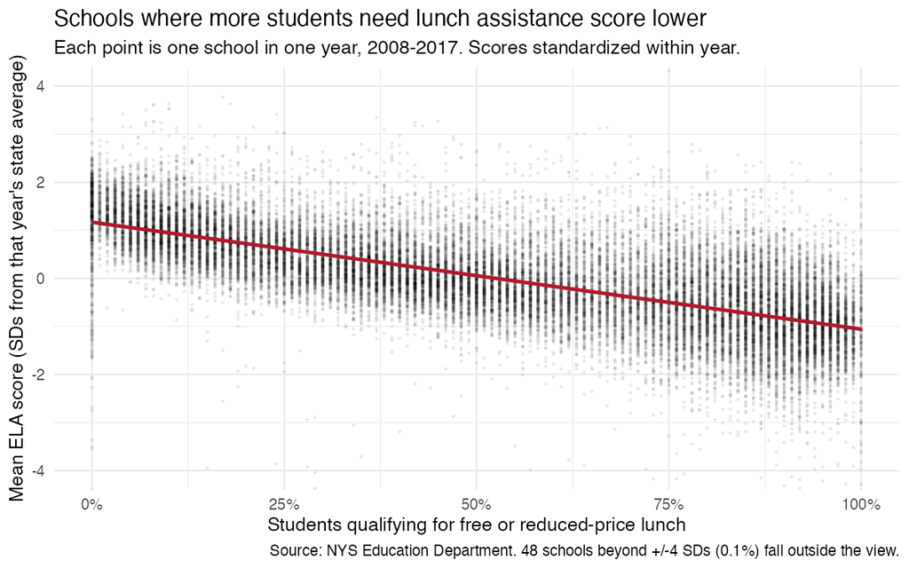

```r
include_graphics("output/figures/1_lunch_vs_score.png")
```

```r
kable(tbl("by_lunch"), digits = 3, caption = "Mean ELA z-score by lunch-access tercile, within each poverty tier")
```

Mean ELA z-score by lunch-access tercile, within each poverty tier

| poverty_group | lunch_tercile | mean_ela_z | n |
| --- | --- | --- | --- |
| low | low | 1.098 | 3183 |
| low | medium | 0.462 | 2895 |
| low | high | -0.392 | 3020 |
| medium | low | 0.691 | 2369 |
| medium | medium | 0.023 | 2352 |
| medium | high | -0.777 | 2333 |
| high | low | 0.375 | 4179 |
| high | medium | -0.365 | 4160 |
| high | high | -0.840 | 3966 |

```r
# Fit the school-level relationship separately in each poverty tier: if lunch
# access moderated the effect, these slopes would differ.
merged |>
  filter(!is.na(poverty_group), !is.na(per_free_reduced), !is.na(mean_ela_score_z)) |>
  group_by(poverty_group) |>
  group_modify(~ {
    fit <- lm(mean_ela_score_z ~ per_free_reduced, data = .x)
    tibble(slope = coef(fit)[2], r_squared = summary(fit)$r.squared, n = nrow(.x))
  }) |>
  kable(digits = 3, caption = "Slope of ELA z-score on free/reduced lunch share")
```

Slope of ELA z-score on free/reduced lunch share

| poverty_group | slope | r_squared | n |
| --- | --- | --- | --- |
| low | -2.671 | 0.539 | 8275 |
| medium | -2.382 | 0.483 | 6688 |
| high | -2.351 | 0.328 | 11742 |

**No.** The slopes are near-identical across tiers (−2.7, −2.4, −2.4), so lunch access doesn’t soften the poverty relationship — it measures the same disadvantage better, explaining 46% of score variance on its own (pooled; the per-tier figures are in the table above). Within high-poverty counties alone, low- vs high-lunch-access schools differ by 1.21 SDs, nearly twice the entire between-county gap.

This is **eligibility, not treatment** — the variable counts students who *qualify* for assistance, so it proxies family poverty. Nothing here says anything about whether the meals help; every eligible student presumably receives them, so the data contains no variation in access to measure.

## Takeaway

The gap is large (0.67 SDs) and closing (0.97 → 0.43). But county poverty is the wrong targeting variable: school-level lunch share predicts performance better, is already collected, and identifies struggling schools inside wealthy counties that a county-level measure would miss.

## Limitations

- Correlational. Lunch access, county poverty and scores are all downstream of the same conditions.
- County poverty is assigned to every school in the county, which isn’t where poverty actually varies.
- School mean scores hide within-school variation.
- Z-scores are relative, so convergence can’t be separated from a test that spreads schools less widely.
- 2,208 ELA scores are missing; if smaller or poorer schools are likelier to be missing, these gaps are understated.
- 2008 and 2017 drop out of county analyses for lack of ACS data.
- Poverty tiers are assigned per county-year, and 38 of 62 counties change tier at some point, so the groups compared in Q2 are not a fixed set of counties.